# KD Practicum 2.1

## Rectangular data

Rectangular data are the staple of machine learning models. They are a suitable representation of multivariate cross-sectional data — i.e. data in which each column is a variable/attribute/feature, and each row is an observation. There are two basic formats that rectangular data come in.

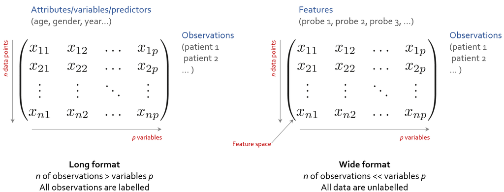

Python and R house rectangular data in **data frames**. Data frames are the most commonly used data type for storing rectangular data, but there exist several simpler models that are better off for specific use cases.

- The simplest data type is an **array**, which is built by using dimensions attribute to **cast, or fold** an atomic vector into a defined shape. Arrays are not as practically as useful as fully-fledged data frames, but their sweet spot lies in storing measurement data.
- Unlike arrays, **matrix** is built by row-/column-binding of atomic vectors with the same type and length. Because each binding unit is an independent vector, matrices are very useful for storing results from iterative computations.
- **List, or recursive vector** acts as a container. Unlike atomic vector, the content of a list is not restricted to a single mode (i.e. integer), but can encompass any data type.

### Arrays

Array is a data storage object containing more than 1, or equal to 1 dimension. Be it made from characters or integers, **array contains only a single data type**. Array is an iterable object, where the array elements are indexed, accessed and modified individually. As you might expect, an **uni-dimensional array** is called **vector**.

### Casting vectors into arrays

Let’s investigate how to build an array by shaping an atomic vector.

**Question 1.** Create an atomic vector of integers 1 through 10.

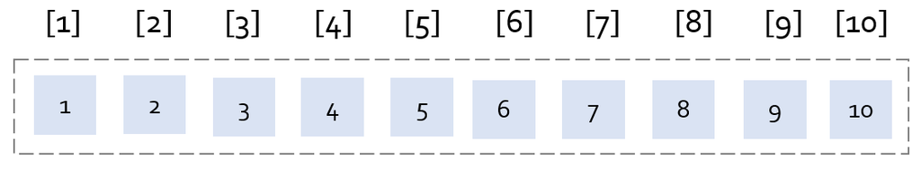

Does `x` have any attributes? Use `attributes()` function to check that out. Does `x` have any rows and columns? Row and column names? Use `rownames()` and `colnames()` to find out.

**Question 2.** Use `dim()`to set dimensions of `x`. Dimensions are provided as an atomic vector (e.g. with `c()`) using the left assignment operator.

The first number in a vector represents the number of rows, The second parameter is the number of columns, and so on. Let’s create an array with two rows and five columns from `x`.

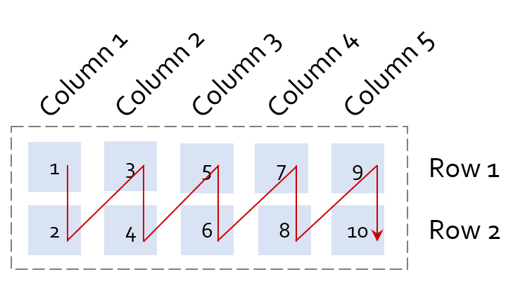

You will find out that arrays are built **column-wise by default**. This is important behaviour to remember, because soon you will be applying higher-order functions to arrays and matrices, and they iterate column-wise by default.

```r
# Create vector x from 10 consecutive integers, starting with 1.
x <- 1:10
# Cast vector x into a matrix that has 2 rows and 2 columns.
dim(x) <- c(2,5)
x
```

```
##      [,1] [,2] [,3] [,4] [,5]
## [1,]    1    3    5    7    9
## [2,]    2    4    6    8   10
```

**Question 3.** An array without names of rows and columns can be very confusing. So, let’s add them by typing arbitrary names using `dimnames(x) <- list(c("Alpha", "Beta"), c("Gamma", "Delta", "Epsilon", "Zeta", "Eta"))`. Use `attributes()`again to see the changes.

```r
# Name rows and columns of matrix x.
dimnames(x) <- list(c("Alpha", "Beta"),
                    c("Gamma", "Delta", "Epsilon","Zeta", "Eta"))
x
```

```
##       Gamma Delta Epsilon Zeta Eta
## Alpha     1     3       5    7   9
## Beta      2     4       6    8  10
```

**Question 4.** By providing new values to `dim()`, you have successfully changed dimensions of `x` without changing the content of `x`. This process is called **casting**. The complement to casting is **melting** — which effectively strips the array’s dim attributes of their current values. But you don’t need go that far. Dimensions of `x` can be changed dynamically without losing array’s content.

Now, let’s use `dim()` to reshape `x` into five-row-and-two-column matrix. You should get the following…

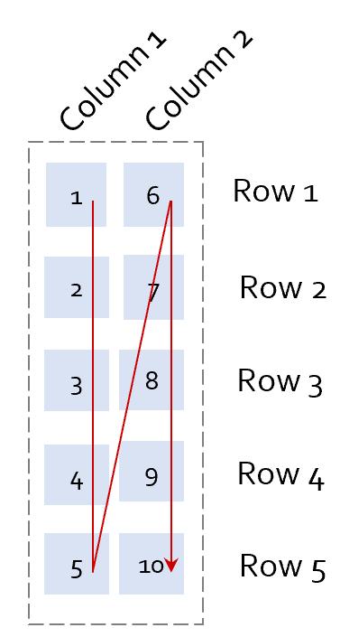

```r
# Change the number of rows to 5 and the number of columns to 2.
dim(x) <- c(5,2) ; x
```

```
##      [,1] [,2]
## [1,]    1    6
## [2,]    2    7
## [3,]    3    8
## [4,]    4    9
## [5,]    5   10
```

What happened to all row and column names?

- Use `attributes()` to check that out.
- Find the way to put them back.

### Matrices

Matrices are a table-like structures consisting of elements arranged in a fixed number of rows and columns. All elements belong to a single data type. R contains an in-built constructor `matrix()` to create matrices.

Matrix elements can be accessed by their indices: row index is provided first, followed by the column index. The arithmetic operations such as addition, subtraction, and multiplication can be performed on matrices as you would expect to work on vectors, which is really cool.

### Assembling matrices by vector-binding

To create a matrix, you can use a dedicated constructor `matrix()`. However, it is often more practical to build matrices by binding different vectors together. The only condition is that vectors to be bound must have the same type and length. Let’s use the constructor to build an empty matrix with 0 rows and 3 columns.

```r
# Build an empty matrix with 3 columns and no rows.
m <- matrix(nrow = 0, ncol = 3, byrow = TRUE)
```

Binding vectors together has a sweet spot in iterative ops. Let’s demonstrate such behavior by filling an empty array with randomly generated numbers from normal distribution. Don’t worry too much about the syntax of loops — this is just to demonstrate the intended historical purpose of matrices.

```r
# Fill an empty matrix with randomly generated triplets.
set.seed(123)
for (i in 1:5) m <- rbind(m, rnorm(n = 3, mean = i)) ; m
```

```
##           [,1]      [,2]     [,3]
## [1,] 0.4395244 0.7698225 2.558708
## [2,] 2.0705084 2.1292877 3.715065
## [3,] 3.4609162 1.7349388 2.313147
## [4,] 3.5543380 5.2240818 4.359814
## [5,] 5.4007715 5.1106827 4.444159
```

The code is executed in five iterations; each of which row-binds a sequence of three numbers to the growing matrix. `rbind()` glues two vectors together, thus eventually forming a matrix.

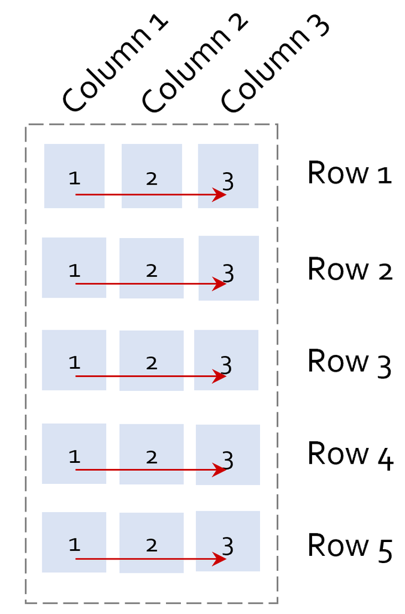

Alternatively, you can built matrices by column binding with `cbind()`.

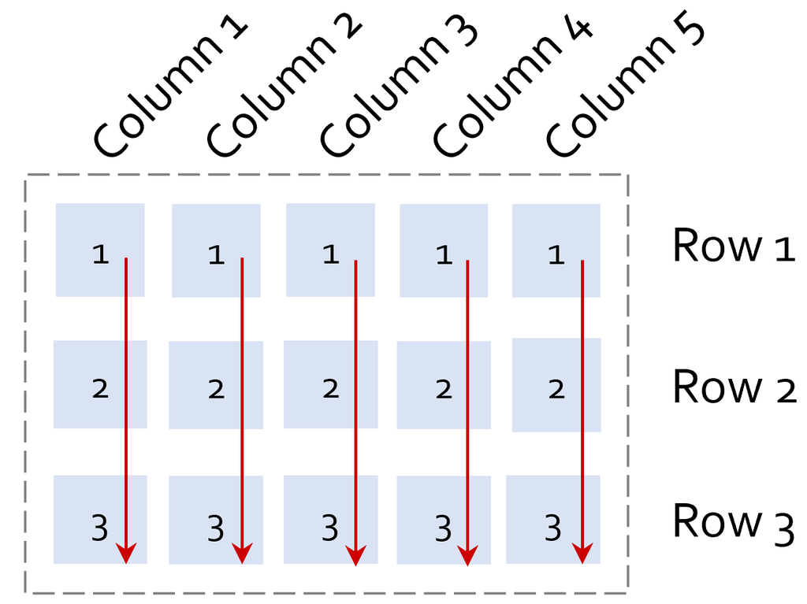

Knowing how to build matrices, let’s explore them a bit.

**Question 5.** Use `typeof()`and `class()` to see what object type and class the matrix `m` actually is. Why is it still considered as an instance of array?

**Question 6.** Reset dimension parameter of `m` by setting it’s value to `NULL`. What type of an object did you get? Is it possible to restore the original vectors, which were used to build `m`?

**Question 7.** Try to rebuild the original matrix from `m` — but this time as an array. Even though you are not familiar with R constructor syntax for arrays, this information is always available to you by typing help(“array”).

**Question 8.** Use R documentation for self-study of the basics of `for` loops and `if` statements. Use them in conjunction with `cbind()` / `rbind()` functions to recreate the original matrix.

At the end, you should get this:

```
##           [,1]      [,2]     [,3]
## [1,] 0.4395244 0.7698225 2.558708
## [2,] 2.0705084 2.1292877 3.715065
## [3,] 3.4609162 1.7349388 2.313147
## [4,] 3.5543380 5.2240818 4.359814
## [5,] 5.4007715 5.1106827 4.444159
```

### Summary

We have shown that arrays and matrices are parametric instances of a vector data type. As such, they are frequently used for storing computation results, but are not very handy when it comes to storing real life data. Let’s review their similarities and differences:

| Arrays | Matrices |
| --- | --- |
| Arrays can contain greater than, or equal to 1 dimensions. | Matrices contains 2 dimensions in a table like structure. |
| Array is a homogeneous data structure. | Matrix is also a homogeneous data structure. |
| It is a singular vector arranged into the specified dimensions. | It comprises of multiple equal length vectors stacked together in a table. |
| `array()` function can be used to create arrays by specifying the third dimension to be 1. | `matrix()` function however can be used to create at most 2-dimensional array. |
| Arrays are superset of matrices. | Matrices are a subset, or special case of array where dimensions attribute is equal to two. |
| Limited set of collection-based operations. | Wide range of collection operations possible. |
| Mostly, intended for storage of measurements. | Mostly, matrices are intended for data transformation. |

The following table shows, how many of the functions for working with vectors have generalizations for matrices and arrays.

| **Operation** | **Vector** | **Matrix** | **Array** |
| --- | --- | --- | --- |
| **Get names** | `names()` | `rownames()`;`colnames()` | `dimnames()` |
| **Get length** | `length()` | `nrow()`;`ncol()` | `dim()` |
| **Append** | `c()` | `rbind()`;`cbind()` | `abind()` |
| **Transpose** | - | `t()` | `aperm()` |